# Project Wine 820

Compare statistics by class and note whether it improved after feature engineering.

knn

Statistics by Class:

```
                 Class: 3 Class: 4 Class: 5 Class: 6 Class: 7 Class: 8 Class: 9
```

Sensitivity 0.000000 0.00000 0.5764 0.7037 0.42697 0.047619 NA Specificity 1.000000 1.00000 0.8410 0.5803 0.89027 0.995736 1 Pos Pred Value NaN NaN 0.6014 0.5693 0.46341 0.333333 NA

knn with fe

```r
confusionMatrix(wine_knn_Conf_Matrix_pca)
```

```
## Confusion Matrix and Statistics
##
##                   wine_knn_test_category_pca
## wine_knn_model_pca   3   4   5   6   7   8   9
##                  3   0   0   0   0   0   0   0
##                  4   0   1   1   0   0   0   0
##                  5   1  11  77  50   4   1   0
##                  6   0   3  67 151  40   7   0
##                  7   0   1   5  30  30   4   0
##                  8   0   0   0   2   3   1   0
##                  9   0   0   0   0   0   0   0
##
## Overall Statistics
##
##                Accuracy : 0.5306
##                  95% CI : (0.4853, 0.5755)
##     No Information Rate : 0.4755
##     P-Value [Acc > NIR] : 0.008296
##
##                   Kappa : 0.2514
##
##  Mcnemar's Test P-Value : NA
##
## Statistics by Class:
##
##                      Class: 3 Class: 4 Class: 5 Class: 6 Class: 7 Class: 8
## Sensitivity          0.000000 0.062500   0.5133   0.6481  0.38961 0.076923
## Specificity          1.000000 0.997890   0.8029   0.5447  0.90315 0.989518
## Pos Pred Value            NaN 0.500000   0.5347   0.5634  0.42857 0.166667
## Neg Pred Value       0.997959 0.969262   0.7890   0.6306  0.88810 0.975207
## Prevalence           0.002041 0.032653   0.3061   0.4755  0.15714 0.026531
## Detection Rate       0.000000 0.002041   0.1571   0.3082  0.06122 0.002041
## Detection Prevalence 0.000000 0.004082   0.2939   0.5469  0.14286 0.012245
## Balanced Accuracy    0.500000 0.530195   0.6581   0.5964  0.64638 0.533220
##                      Class: 9
## Sensitivity                NA
## Specificity                 1
## Pos Pred Value             NA
## Neg Pred Value             NA
## Prevalence                  0
## Detection Rate              0
## Detection Prevalence        0
## Balanced Accuracy          NA
```

```r
confusionMatrix(wine_knn_Conf_Matrix_pca_5)
```

```
## Confusion Matrix and Statistics
##
##                     wine_knn_test_category_pca
## wine_knn_model_pca_5   3   4   5   6   7   8   9
##                    3   0   0   0   0   0   0   0
##                    4   0   1   2   2   0   0   0
##                    5   1  13  72  46   5   2   0
##                    6   0   0  66 154  33   5   0
##                    7   0   2   8  29  38   3   0
##                    8   0   0   2   2   1   3   0
##                    9   0   0   0   0   0   0   0
##
## Overall Statistics
##
##                Accuracy : 0.5469
##                  95% CI : (0.5017, 0.5916)
##     No Information Rate : 0.4755
##     P-Value [Acc > NIR] : 0.0009072
##
##                   Kappa : 0.2881
##
##  Mcnemar's Test P-Value : NA
##
## Statistics by Class:
##
##                      Class: 3 Class: 4 Class: 5 Class: 6 Class: 7 Class: 8
## Sensitivity          0.000000 0.062500   0.4800   0.6609  0.49351 0.230769
## Specificity          1.000000 0.991561   0.8029   0.5953  0.89831 0.989518
## Pos Pred Value            NaN 0.200000   0.5180   0.5969  0.47500 0.375000
## Neg Pred Value       0.997959 0.969072   0.7778   0.6595  0.90488 0.979253
## Prevalence           0.002041 0.032653   0.3061   0.4755  0.15714 0.026531
## Detection Rate       0.000000 0.002041   0.1469   0.3143  0.07755 0.006122
## Detection Prevalence 0.000000 0.010204   0.2837   0.5265  0.16327 0.016327
## Balanced Accuracy    0.500000 0.527031   0.6415   0.6281  0.69591 0.610144
##                      Class: 9
## Sensitivity                NA
## Specificity                 1
## Pos Pred Value             NA
## Neg Pred Value             NA
## Prevalence                  0
## Detection Rate              0
## Detection Prevalence        0
## Balanced Accuracy          NA
```

```r
# Test area to figure out why overall precision and recall does not show up in results. Only category specific precision and recall metrics are shown.

#wine_knn_Conf_Matrix_fe_num <- table(wine_knn_model_fe_num, wine_knn_test_category_fe_num)
#confusionMatrix(wine_knn_Conf_Matrix_fe_num)
#wine_knn_Conf_Matrix_fe_num
```

```r
# K-fold for KNN starts below
```

```r
# code trControl grid method here


#trControl <- trainControl(method = "cv",
#    number = 10,
#    search = "grid")

#trControl_ran <- trainControl(method = "cv",
#    number = 10,
#    search = "random")
```

```r
# code trControl search method here
```

```r
# verify knn data for training... might need to use data with quality in it
```

```r
#set.seed(1)
#rf_time_cv_grid <- system.time(rf_default_grid <- train(quality~.,
#                    data = wine_rf_train,
#                    method = "rf",
#                    metric = "Accuracy",
#                    trControl = trControl))

#print(rf_default_grid)
#rf_time_cv_grid

#set.seed(1)
#knn_time_cv_grid <- system.time(knn_default_grid <- train(quality~.,
#                    data = wine_rf_train, #change to knn train data
#                    method = "knn",
#                    metric = "Accuracy",
#                    trControl = trControl))

#print(rf_default_grid)
#rf_time_cv_grid
```

```r
################################################################################

              ####      ######
              #   #     #
              ###       ####
              #  #      #
              #   #     #

###############################################################################


# Random Forest starts below


library(randomForest)
```

```r
library(ggplot2) # Data visualization
# library(readr) # CSV file I/O, e.g. the read_csv function
```

```r
# Train and Test sets for Random forest model
wine_rf_train <- wine[wine_ran,]
#wine_rf_train_norm <- wine_knn_norm[wine_ran,]

wine_rf_test <- wine[-wine_ran,]
#wine_rf_test_norm <- wine_knn_norm[-wine_ran,]

#head(wine_rf_test_norm)
```

```r
str(wine_rf_test)
```

```
## 'data.frame':    490 obs. of  12 variables:
##  $ fixed.acidity       : num  7 8.1 7.6 5.8 6.7 7 7.4 6.2 6.9 7.4 ...
##  $ volatile.acidity    : num  0.27 0.22 0.67 0.27 0.24 0.31 0.18 0.16 0.25 0.2 ...
##  $ citric.acid         : num  0.36 0.43 0.14 0.2 0.39 0.26 0.31 0.33 0.35 0.36 ...
##  $ residual.sugar      : num  20.7 1.5 1.5 14.9 2.9 ...
##  $ chlorides           : num  0.045 0.044 0.074 0.044 0.173 0.069 0.058 0.057 0.039 0.038 ...
##  $ free.sulfur.dioxide : num  45 28 25 22 63 28 38 21 29 44 ...
##  $ total.sulfur.dioxide: num  170 129 168 179 157 160 167 82 191 111 ...
##  $ density             : num  1.001 0.994 0.994 0.996 0.994 ...
##  $ pH                  : num  3 3.22 3.05 3.37 3.1 3.13 3.16 3.32 3.13 3.36 ...
##  $ sulphates           : num  0.45 0.45 0.51 0.37 0.34 0.46 0.53 0.46 0.52 0.34 ...
##  $ alcohol             : num  8.8 11 9.3 10.2 9.4 9.8 10 10.9 11 9.9 ...
##  $ quality             : Factor w/ 7 levels "3","4","5","6",..: 4 4 3 3 4 4 5 5 4 4 ...
```

```r
#str(wine_rf_test_norm)
```

```r
###
#Create random forest model with 1000 trees and 7 random variables

rf_time<- system.time(model <- randomForest(quality ~ ., data = wine, importance=TRUE, proximity=TRUE, ntree=1000, mtry=7))

rf_time
```

```
##    user  system elapsed
##  60.361   0.668  61.038
```

```r
model
```

```
##
## Call:
##  randomForest(formula = quality ~ ., data = wine, importance = TRUE,      proximity = TRUE, ntree = 1000, mtry = 7)
##                Type of random forest: classification
##                      Number of trees: 1000
## No. of variables tried at each split: 7
##
##         OOB estimate of  error rate: 28.91%
## Confusion matrix:
##   3  4    5    6   7  8 9 class.error
## 3 0  0    9   11   0  0 0   1.0000000
## 4 0 46   79   37   1  0 0   0.7177914
## 5 0  9 1047  390  10  1 0   0.2814001
## 6 0  2  276 1788 128  4 0   0.1865332
## 7 0  0   15  336 520  9 0   0.4090909
## 8 0  0    2   48  44 81 0   0.5371429
## 9 0  0    1    2   2  0 0   1.0000000
```

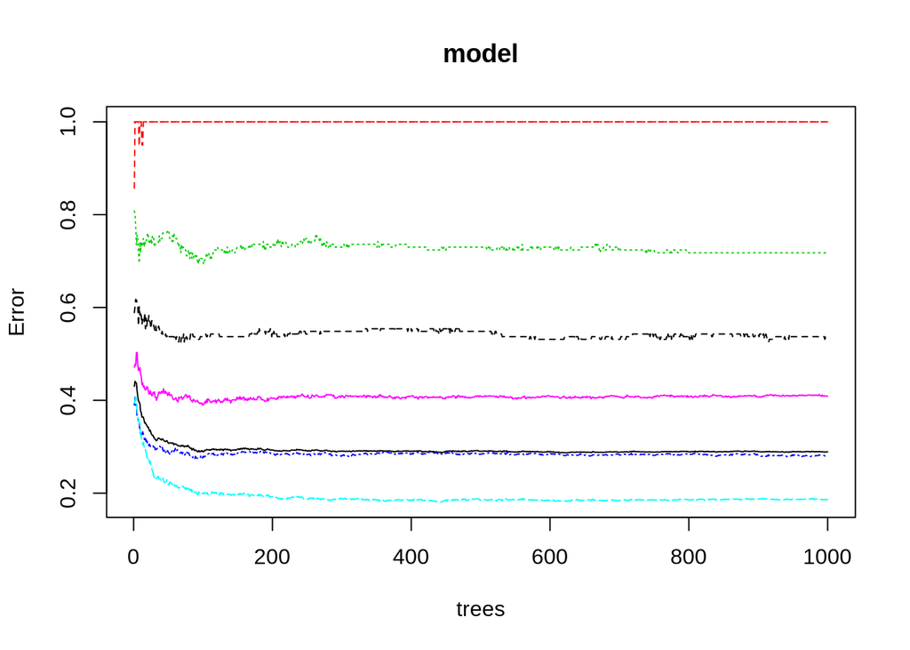

```r
plot(model)
```

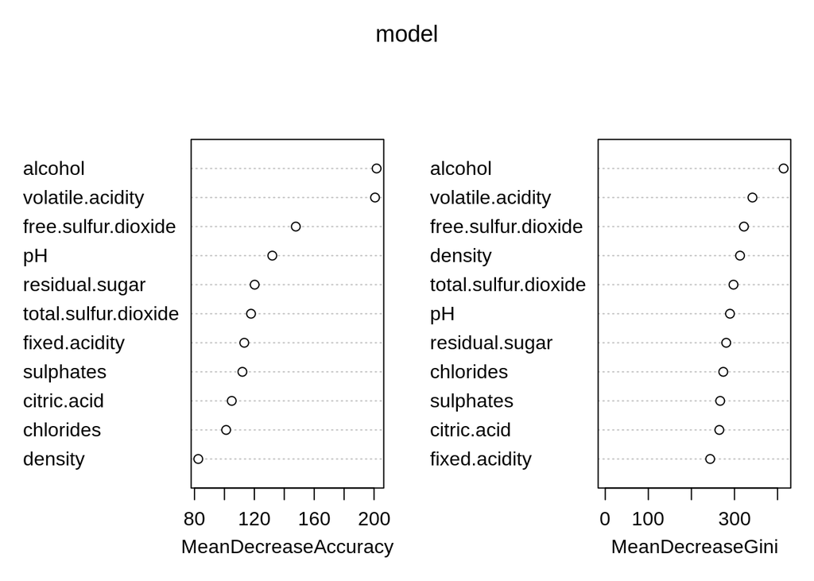

```r
#Check out importance variables in order to find which features are important.

varImpPlot(model)
```

```r
# The most important features are likely to appear closer to the root of the tree, while less important features will often appear close to the leaves.
```

These two were first shown MSE = mean square error(?)

Node Purity - find out what this means

After subsequent runs, these two showed up

```
Mean Decrease Accuracy
      - is also (%IncMSE)
      - This shows how much our model accuracy decreases if we                                         leave out that variable

Mean Decrease Gini
      - is also (IncNodePurity)
      - This is a measure of variable importance based on Gini impurity index used for                 calculating the splits in trees


The higher the value of mean decrease accuracy or mean decrease gini, the higher the importance of the variable to our model


Since Fixed.acidity, chlorides and citric acid are in the bottom half of both measures. I chose to remove these features.
```

from Prof Erdem,

top 3 features are important and the fact that both graphs show it means it’s really important

use and check performance : top 6 features and knee points and overlap …

```r
#  Random forest code with cross validation using k-folds starts below

library(randomForest)
library(caret)
library(e1071)
```

```r
# k-folds with k = 10

trControl <- trainControl(method = "cv",
    number = 10,
    search = "grid")

trControl_ran <- trainControl(method = "cv",
    number = 10,
    search = "random")
```

train(formula, df, method = “rf”, metric= “Accuracy”, trControl = trainControl(), tuneGrid = NULL) argument - `formula`: Define the formula of the algorithm - `method`: Define which model to train. Note, at the end of the tutorial, there is a list of all the models that can be trained - `metric` = “Accuracy”: Define how to select the optimal model - `trControl = trainControl()`: Define the control parameters - `tuneGrid = NULL`: Return a data frame with all the possible combination

```r
set.seed(1)
rf_time_cv_grid <- system.time(rf_default_grid <- train(quality~.,
                    data = wine_rf_train,
                    method = "rf",
                    metric = "Accuracy",
                    trControl = trControl))

print(rf_default_grid)
```

```
## Random Forest
##
## 4408 samples
##   11 predictor
##    7 classes: '3', '4', '5', '6', '7', '8', '9'
##
## No pre-processing
## Resampling: Cross-Validated (10 fold)
## Summary of sample sizes: 3967, 3967, 3968, 3967, 3966, 3967, ...
## Resampling results across tuning parameters:
##
##   mtry  Accuracy   Kappa
##    2    0.6934942  0.5239180
##    6    0.6823860  0.5094730
##   11    0.6798788  0.5069678
##
## Accuracy was used to select the optimal model using the largest value.
## The final value used for the model was mtry = 2.
```

```r
rf_time_cv_grid
```

```
##    user  system elapsed
## 126.121   0.933 127.074
```

The best accuracy which is equal to 69.34 % where mtry = 2

The algorithm used 500 trees as a default and tested 3 different values of mtry : 2, 6 11.

```r
# random option for trControl
set.seed(1)
rf_time_cv_search_500 <- system.time(rf_default_search_500 <- train(quality~.,
                    data = wine_rf_train,
                    method = "rf",
                    metric = "Accuracy",
                    trControl = trControl_ran,
                    ))

rf_default_search_500
```

```
## Random Forest
##
## 4408 samples
##   11 predictor
##    7 classes: '3', '4', '5', '6', '7', '8', '9'
##
## No pre-processing
## Resampling: Cross-Validated (10 fold)
## Summary of sample sizes: 3967, 3967, 3968, 3967, 3966, 3967, ...
## Resampling results across tuning parameters:
##
##   mtry  Accuracy   Kappa
##   1     0.6901036  0.5159173
##   2     0.6896557  0.5179081
##   7     0.6819176  0.5091821
##
## Accuracy was used to select the optimal model using the largest value.
## The final value used for the model was mtry = 1.
```

Using the random search method for train control, the best accuracy is equal to 69.01 % where mtry = 1. The accuracy is slightly worse than grid method.

The algorithm used 500 trees as a default and tested 3 different values of mtry : 1, 2, 7.

```r
rf_time_cv_search_500
```

```
##    user  system elapsed
## 114.559   0.618 115.246
```

```r
set.seed(1)
rf_time_cv_grid_1000 <- system.time(rf_default_grid_1000 <- train(quality~.,
                    data = wine_rf_train,
                    method = "rf",
                    metric = "Accuracy",
                    trControl = trControl,
                    ntree = 1000))
```

```r
rf_time_cv_grid_1000
```

```
##    user  system elapsed
## 252.843   2.654 255.776
```

```r
print(rf_default_grid_1000)
```

```
## Random Forest
##
## 4408 samples
##   11 predictor
##    7 classes: '3', '4', '5', '6', '7', '8', '9'
##
## No pre-processing
## Resampling: Cross-Validated (10 fold)
## Summary of sample sizes: 3967, 3967, 3968, 3967, 3966, 3967, ...
## Resampling results across tuning parameters:
##
##   mtry  Accuracy   Kappa
##    2    0.6928083  0.5221445
##    6    0.6826076  0.5094240
##   11    0.6812342  0.5086601
##
## Accuracy was used to select the optimal model using the largest value.
## The final value used for the model was mtry = 2.
```

Using the grid method for train control and setting ntree = 1000, the best accuracy which is equal to 69.28 % where mtry = 2.

The algorithm used 1000 trees and tested 3 different values of mtry : 2, 6 11. It also required about 253 seconds vs 128 for ntree = 500.

The increase in ntree value did not improve the accuracy of the model

Next, we add tuneGrid to see if we can get better accuracy:

```r
set.seed(1)
tuneGrid <- expand.grid(.mtry = c(1: 10))
rf_time_cv_mtry <- system.time(rf_mtry <- train(quality~.,
    data = wine_rf_train,
    method = "rf",
    metric = "Accuracy",
    tuneGrid = tuneGrid,
    trControl = trControl,
    ntree = 500))
```

```r
print(rf_mtry)
```

```
## Random Forest
##
## 4408 samples
##   11 predictor
##    7 classes: '3', '4', '5', '6', '7', '8', '9'
##
## No pre-processing
## Resampling: Cross-Validated (10 fold)
## Summary of sample sizes: 3967, 3967, 3968, 3967, 3966, 3967, ...
## Resampling results across tuning parameters:
##
##   mtry  Accuracy   Kappa
##    1    0.6937293  0.5211796
##    2    0.6866898  0.5128945
##    3    0.6903267  0.5197810
##    4    0.6857813  0.5138290
##    5    0.6855555  0.5144570
##    6    0.6817021  0.5084398
##    7    0.6810280  0.5078542
##    8    0.6769273  0.5011947
##    9    0.6801179  0.5065980
##   10    0.6780760  0.5039923
##
## Accuracy was used to select the optimal model using the largest value.
## The final value used for the model was mtry = 1.
```

```r
rf_time_cv_mtry
```

```
##    user  system elapsed
## 396.627   0.917 397.656
```

Adding tunegrid and setting mtry to use 1:10 and setting ntree = 500, the best accuracy which is equal to 69.37 % where mtry = 1.

The algorithm used 500 trees and tested 10 different values of mtry. It also required about 398 seconds vs 128 for the default setting of 3 mtry values.

The addition of tune did improve the accuracy of the model for this dataset by a very small increase of 0.03 percent over the default settings.

```r
# model evaluation

# using the predict function in the library caret:

# Here, rf_default_grid model used for test dataset (wine_rf_test).

prediction_rf <- predict(rf_default_grid, wine_rf_test)
```

```r
prediction_rf_model <- predict(model, wine_rf_test)
```

```r
# using confusionMatrix to get accuracy.

confusionMatrix(prediction_rf, wine_rf_test$quality)
```

```
## Confusion Matrix and Statistics
##
##           Reference
## Prediction   3   4   5   6   7   8   9
##          3   0   0   0   0   0   0   0
##          4   0   5   0   1   0   0   0
##          5   0   8 115  32   0   0   0
##          6   1   3  35 189  38   4   0
##          7   0   0   0  11  39   2   0
##          8   0   0   0   0   0   7   0
##          9   0   0   0   0   0   0   0
##
## Overall Statistics
##
##                Accuracy : 0.7245
##                  95% CI : (0.6826, 0.7636)
##     No Information Rate : 0.4755
##     P-Value [Acc > NIR] : < 2.2e-16
##
##                   Kappa : 0.5583
##
##  Mcnemar's Test P-Value : NA
##
## Statistics by Class:
##
##                      Class: 3 Class: 4 Class: 5 Class: 6 Class: 7 Class: 8
## Sensitivity          0.000000  0.31250   0.7667   0.8112  0.50649  0.53846
## Specificity          1.000000  0.99789   0.8824   0.6848  0.96852  1.00000
## Pos Pred Value            NaN  0.83333   0.7419   0.7000  0.75000  1.00000
## Neg Pred Value       0.997959  0.97727   0.8955   0.8000  0.91324  0.98758
## Prevalence           0.002041  0.03265   0.3061   0.4755  0.15714  0.02653
## Detection Rate       0.000000  0.01020   0.2347   0.3857  0.07959  0.01429
## Detection Prevalence 0.000000  0.01224   0.3163   0.5510  0.10612  0.01429
## Balanced Accuracy    0.500000  0.65520   0.8245   0.7480  0.73751  0.76923
##                      Class: 9
## Sensitivity                NA
## Specificity                 1
## Pos Pred Value             NA
## Neg Pred Value             NA
## Prevalence                  0
## Detection Rate              0
## Detection Prevalence        0
## Balanced Accuracy          NA
```

The model produced an accuracy of 72.45 %. This is better than the other training sets’ accuracy.

Why? Needs more research and reading!

```r
confusionMatrix(prediction_rf_model, wine_rf_test$quality)
```

```
## Confusion Matrix and Statistics
##
##           Reference
## Prediction   3   4   5   6   7   8   9
##          3   1   0   0   0   0   0   0
##          4   0  16   0   0   0   0   0
##          5   0   0 150   0   0   0   0
##          6   0   0   0 233   0   0   0
##          7   0   0   0   0  77   0   0
##          8   0   0   0   0   0  13   0
##          9   0   0   0   0   0   0   0
##
## Overall Statistics
##
##                Accuracy : 1
##                  95% CI : (0.9925, 1)
##     No Information Rate : 0.4755
##     P-Value [Acc > NIR] : < 2.2e-16
##
##                   Kappa : 1
##
##  Mcnemar's Test P-Value : NA
##
## Statistics by Class:
##
##                      Class: 3 Class: 4 Class: 5 Class: 6 Class: 7 Class: 8
## Sensitivity          1.000000  1.00000   1.0000   1.0000   1.0000  1.00000
## Specificity          1.000000  1.00000   1.0000   1.0000   1.0000  1.00000
## Pos Pred Value       1.000000  1.00000   1.0000   1.0000   1.0000  1.00000
## Neg Pred Value       1.000000  1.00000   1.0000   1.0000   1.0000  1.00000
## Prevalence           0.002041  0.03265   0.3061   0.4755   0.1571  0.02653
## Detection Rate       0.002041  0.03265   0.3061   0.4755   0.1571  0.02653
## Detection Prevalence 0.002041  0.03265   0.3061   0.4755   0.1571  0.02653
## Balanced Accuracy    1.000000  1.00000   1.0000   1.0000   1.0000  1.00000
##                      Class: 9
## Sensitivity                NA
## Specificity                 1
## Pos Pred Value             NA
## Neg Pred Value             NA
## Prevalence                  0
## Detection Rate              0
## Detection Prevalence        0
## Balanced Accuracy          NA
```

```r
# do Random Forest with FE

# use rf_default_grid model with subset data that removed fixed acidity , ...

#subset_wine_W <- wine_W[,c("fixed.acidity","residual.sugar", "pH", "sulphates", "alcohol", "quality")]

wine_rf_train_fe <- wine_rf_train[,c( "volatile.acidity" , "residual.sugar" , "free.sulfur.dioxide" , "total.sulfur.dioxide", "density" , "pH",  "sulphates" , "alcohol", "quality")]

wine_rf_train_pca <- wine_rf_train[,c( "volatile.acidity" , "residual.sugar" , "free.sulfur.dioxide" , "total.sulfur.dioxide", "density" , "pH",  "sulphates" , "alcohol", "quality")]

set.seed(1)
rf_time_cv_grid_fe <- system.time(rf_default_grid_fe <- train(quality~.,
                    data = wine_rf_train_fe, # replace with fe subset
                    method = "rf",
                    metric = "Accuracy",
                    trControl = trControl))
```

```r
print(rf_default_grid_fe)
```

```
## Random Forest
##
## 4408 samples
##    8 predictor
##    7 classes: '3', '4', '5', '6', '7', '8', '9'
##
## No pre-processing
## Resampling: Cross-Validated (10 fold)
## Summary of sample sizes: 3967, 3967, 3968, 3967, 3966, 3967, ...
## Resampling results across tuning parameters:
##
##   mtry  Accuracy   Kappa
##   2     0.6837369  0.5112584
##   5     0.6737671  0.4984996
##   8     0.6728461  0.4976098
##
## Accuracy was used to select the optimal model using the largest value.
## The final value used for the model was mtry = 2.
```

```r
rf_time_cv_grid_fe
```

```
##    user  system elapsed
## 103.156   0.537 103.709
```

```r
system.time(prediction_rf_fe <- predict(rf_default_grid_fe, wine_rf_test))
```

```
##    user  system elapsed
##   0.069   0.000   0.070
```

```r
confusionMatrix(prediction_rf_fe, wine_rf_test$quality)
```

```
## Confusion Matrix and Statistics
##
##           Reference
## Prediction   3   4   5   6   7   8   9
##          3   0   0   0   0   0   0   0
##          4   0   6   0   0   0   0   0
##          5   0   7 118  37   1   0   0
##          6   1   3  30 185  35   4   0
##          7   0   0   2  11  39   1   0
##          8   0   0   0   0   2   8   0
##          9   0   0   0   0   0   0   0
##
## Overall Statistics
##
##                Accuracy : 0.7265
##                  95% CI : (0.6848, 0.7655)
##     No Information Rate : 0.4755
##     P-Value [Acc > NIR] : < 2.2e-16
##
##                   Kappa : 0.5658
##
##  Mcnemar's Test P-Value : NA
##
## Statistics by Class:
##
##                      Class: 3 Class: 4 Class: 5 Class: 6 Class: 7 Class: 8
## Sensitivity          0.000000  0.37500   0.7867   0.7940  0.50649  0.61538
## Specificity          1.000000  1.00000   0.8676   0.7160  0.96610  0.99581
## Pos Pred Value            NaN  1.00000   0.7239   0.7171  0.73585  0.80000
## Neg Pred Value       0.997959  0.97934   0.9021   0.7931  0.91304  0.98958
## Prevalence           0.002041  0.03265   0.3061   0.4755  0.15714  0.02653
## Detection Rate       0.000000  0.01224   0.2408   0.3776  0.07959  0.01633
## Detection Prevalence 0.000000  0.01224   0.3327   0.5265  0.10816  0.02041
## Balanced Accuracy    0.500000  0.68750   0.8272   0.7550  0.73630  0.80560
##                      Class: 9
## Sensitivity                NA
## Specificity                 1
## Pos Pred Value             NA
## Neg Pred Value             NA
## Prevalence                  0
## Detection Rate              0
## Detection Prevalence        0
## Balanced Accuracy          NA
```

72.65 % after FE

```r
rf_time_cv_grid
```

```
##    user  system elapsed
## 126.121   0.933 127.074
```

```r
rf_time_cv_grid_fe
```

```
##    user  system elapsed
## 103.156   0.537 103.709
```

Even though FE improves run time by 23 seconds, the cost of slightly lower accuracy is not a worth it.

plot run times for each RF model iteration for presentation purposes.

place all run times to a vector and plot

rf_time_plot <- c[rf_time,rf_time_cv_grid, rf_time_cv_grid_1000]

```r
# create data.frame to hold all run time values

rf_rt_grid_500 <- data.frame("grid 500",
                             rf_time_cv_grid["elapsed"],
                             rf_default_grid$results$Accuracy[1])
names(rf_rt_grid_500) <- c("RF", "Time", "Accuracy")
rf_run_time_df2 <- rbind(rf_rt_grid_500)

rf_rt_grid_1000 <- data.frame("grid 1000",
                              rf_time_cv_grid_1000["elapsed"],
                              rf_default_grid_1000$results$Accuracy[1])
names(rf_rt_grid_1000) <- c("RF", "Time", "Accuracy")
rf_run_time_df2 <- rbind(rf_run_time_df2, rf_rt_grid_1000)

rf_rt_search_500 <- data.frame("search 500",
                               rf_time_cv_search_500["elapsed"],
                               rf_default_search_500$results$Accuracy[1])
names(rf_rt_search_500) <- c("RF", "Time", "Accuracy")
rf_run_time_df2 <- rbind(rf_run_time_df2, rf_rt_search_500)

rf_rt_mtry <- data.frame("mtry",
                         rf_time_cv_mtry["elapsed"],
                         rf_mtry$results$Accuracy[5])
names(rf_rt_mtry) <- c("RF", "Time", "Accuracy")
rf_run_time_df2 <- rbind(rf_run_time_df2, rf_rt_mtry)

rf_rt_grid_fe <- data.frame("grid fe",
                            rf_time_cv_grid_fe["elapsed"],
                            rf_default_grid_fe$results$Accuracy[1])
names(rf_rt_grid_fe) <- c("RF", "Time", "Accuracy")
rf_run_time_df2 <- rbind(rf_run_time_df2, rf_rt_grid_fe)

#rf_run_time_df1 <- as.data.frame(rf_run_time_df1)
```

```r
#str(rf_default)

#rf_default$results$Accuracy[1]
```

```r
str(rf_run_time_df2)
```

```
## 'data.frame':    5 obs. of  3 variables:
##  $ RF      : Factor w/ 5 levels "grid 500","grid 1000",..: 1 2 3 4 5
##  $ Time    : num  127 256 115 398 104
##  $ Accuracy: num  0.693 0.693 0.69 0.686 0.684
```

```r
#rf_run_time_df["elapsed"]

rf_run_time_df2
```

```
##                  RF    Time  Accuracy
## elapsed    grid 500 127.074 0.6934942
## elapsed1  grid 1000 255.776 0.6928083
## elapsed2 search 500 115.246 0.6901036
## elapsed3       mtry 397.656 0.6855555
## elapsed4    grid fe 103.709 0.6837369
```

```r
# now add accuracy from each iteration
```

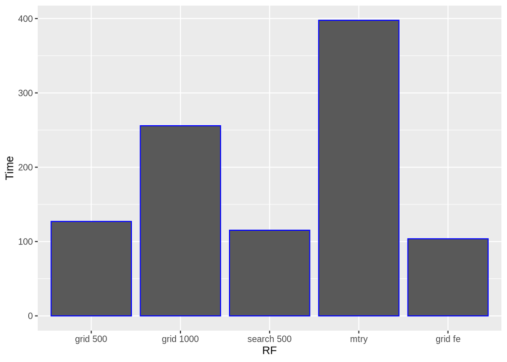

```r
ggplot() +
        geom_col(data = rf_run_time_df2,
       aes( x=RF, y = Time), colour = 'blue')
```

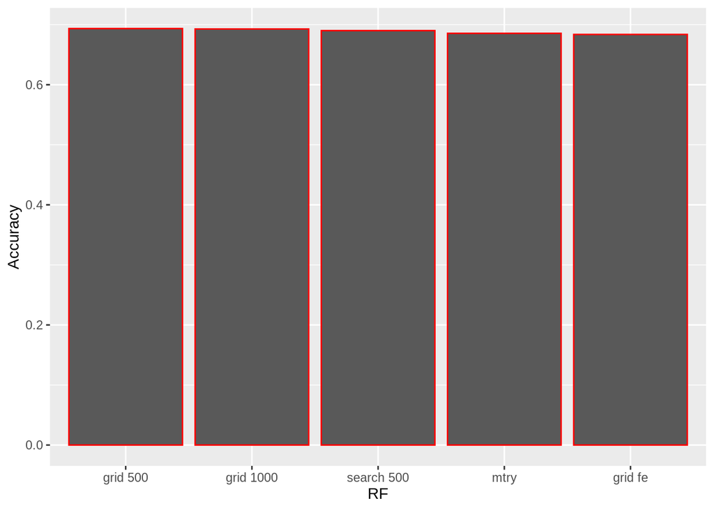

```r
ggplot() +
        geom_col(data = rf_run_time_df2,
       aes( x=RF, y = Accuracy), colour = 'red')
```

As the graph for accuracy shows, there is very little difference from one RF model to the next. The next factor to consider when using the RF model is the run time.

```r
#hist(rf_run_time_df1)
```

```r
### Why normalize?

#Normalize data between 0 and 1
norm <- function(x) {(x - min(x, na.rm=TRUE))/(max(x,na.rm=TRUE) -
min(x, na.rm=TRUE))}
wine$fixed.acidity <- norm(wine$fixed.acidity)
wine$volatile.acidity <- norm(wine$volatile.acidity)
wine$citric.acid <- norm(wine$citric.acid)
wine$residual.sugar <- norm(wine$residual.sugar)
wine$chlorides <- norm(wine$chlorides)
wine$free.sulfur.dioxide <- norm(wine$free.sulfur.dioxide)
wine$total.sulfur.dioxide <- norm(wine$total.sulfur.dioxide)
wine$density <- norm(wine$density)
wine$pH <- norm(wine$pH)
wine$sulphates <- norm(wine$sulphates)
wine$alcohol <- norm(wine$alcohol)
```

```r
################################################################################

# NN starts here               #     #    #     #
                               # #   #    # #   #
                               #  #  #    #  #  #
                               #   # #    #   # #
                               #     #    #     #

################################################################################

# NN starts here
# solving classification problems with neuralnet
# https://datascienceplus.com/neuralnet-train-and-test-neural-networks-using-r/

#Neural Network
#install.packages(neuralnet)
# seems like we just need to call the library(neuralnet)

library(neuralnet)
#library(nnet)
```

```r
# Training and Test Data

# The data is normalized for Neural Networks just like it is for KNN. Among the best practices for training a neural network is to normalize your data. Generally, this speeds up learning and leads to faster convergence.

wine_nn_norm <- as.data.frame(lapply(wine_data_nn[,c(1,2,3,4,5,6,7,8,9,10,11,12)], norm))

#trainset <- maxmindf[1:160, ]
#testset <- maxmindf[161:200, ]

#wine_knn_train <- wine_knn_norm[wine_ran,]
# wine_ran in line 251 , randomizer
wine_nn_train <- wine_nn_norm[wine_ran,]

##extract testing set
 #iris_test <- iris_norm[-ran,]

#wine_knn_test <- wine_knn_norm[-wine_ran,]
wine_nn_test <- wine_nn_norm[-wine_ran,]
```

```r
# Multiclass Classification

nn_time <- system.time(wine_nn <- neuralnet(quality ~ fixed.acidity+ volatile.acidity + citric.acid + residual.sugar + chlorides + free.sulfur.dioxide + total.sulfur.dioxide + density + pH + sulphates + alcohol, data = wine_nn_train, hidden=c(2,1), linear.output=FALSE, threshold=0.01))


#wine_nn <- nnet(quality ~ fixed.acidity+ volatile.acidity + citric.acid + residual.sugar + chlorides + free.sulfur.dioxide + total.sulfur.dioxide + density + pH + sulphates + alcohol, data = wine_nn_train, size = 2, hidden=c(2,1), linear.output=FALSE, threshold=0.01)
```

```r
#print(wine_nn)
nn_time
```

```
##    user  system elapsed
## 132.163 170.234  75.633
```

```r
#nn$result.matrix

wine_nn$result.matrix
```

```
##                                           [,1]
## error                             3.301647e+01
## reached.threshold                 9.853732e-03
## steps                             1.835600e+04
## Intercept.to.1layhid1            -3.164440e+00
## fixed.acidity.to.1layhid1         7.883210e+00
## volatile.acidity.to.1layhid1      7.571986e+00
## citric.acid.to.1layhid1           2.617695e+00
## residual.sugar.to.1layhid1        2.109477e+01
## chlorides.to.1layhid1            -7.813077e+00
## free.sulfur.dioxide.to.1layhid1   1.663969e+00
## total.sulfur.dioxide.to.1layhid1  1.895767e-01
## density.to.1layhid1              -5.016889e+01
## pH.to.1layhid1                    7.301067e+00
## sulphates.to.1layhid1             2.490682e+00
## alcohol.to.1layhid1              -3.425863e+00
## Intercept.to.1layhid2             7.283744e-01
## fixed.acidity.to.1layhid2        -6.917222e-01
## volatile.acidity.to.1layhid2     -3.291100e+00
## citric.acid.to.1layhid2          -4.782151e-01
## residual.sugar.to.1layhid2       -3.170956e-01
## chlorides.to.1layhid2             5.847168e-01
## free.sulfur.dioxide.to.1layhid2   3.877337e-01
## total.sulfur.dioxide.to.1layhid2  7.297774e-02
## density.to.1layhid2               3.468703e+00
## pH.to.1layhid2                   -8.301768e-01
## sulphates.to.1layhid2            -7.084977e-02
## alcohol.to.1layhid2               1.031657e+00
## Intercept.to.2layhid1            -7.801048e+00
## 1layhid1.to.2layhid1              4.921269e+00
## 1layhid2.to.2layhid1              1.149589e+01
## Intercept.to.quality             -9.740438e-01
## 2layhid1.to.quality               1.703209e+00
```

Comparison

NN

NN_FE

```r
#plot(nn)
plot(wine_nn)
```

Testing the accuracy of the NN model.

The subset function is used to eliminate the dependent variable from the test data.

The compute function then creates the prediction variable.

A results variable then compares the predicted data with actual data.

A confusion matrix is then created with the table function.

```r
#Test the resulting output
#temp_test <- subset(testset, select = c("fcfps","earnings_growth", "de", "mcap", "current_ratio"))

temp_nn_test <- subset(wine_nn_test, select =
                         c("fixed.acidity", "volatile.acidity" , "citric.acid" ,
                           "residual.sugar" , "chlorides" , "free.sulfur.dioxide" ,
                           "total.sulfur.dioxide", "density" , "pH",  "sulphates" ,
                           "alcohol"))
#head(temp_nn_test)
#head(temp_test)
```

```r
wine_nn_results <- compute(wine_nn, temp_nn_test)

# wine_nn_results_fe <- compute(wine_nn_fe, temp_nn_test_fe)
# checking code to compare function call for nn computation
# str(wine_nn_results)
```

```r
#results <- data.frame(actual = testset$dividend, prediction = nn.results$net.result)

nn.results <- data.frame(actual = wine_nn_test$quality, prediction = wine_nn_results$net.result )

#nn.results
```

```r
rounded_nn_results <- sapply(nn.results, round, digits=0)

#roundedresultsdf=data.frame(roundedresults)

rounded_nn_results_df = data.frame(rounded_nn_results)

nn_tab <- table(rounded_nn_results_df$actual, rounded_nn_results_df$prediction)

nn_tab
```

```
##
##       0   1
##   0 303  97
##   1  16  74
```

```r
#head(rounded_nn_results_df)
#str(rounded_nn_results_df)
```

```r
#install.packages('e1071', dependencies = TRUE)
#library(caret)
```

```r
#confusionMatrix(rounded_nn_results_df)
confusionMatrix(nn_tab)
```

```
## Confusion Matrix and Statistics
##
##
##       0   1
##   0 303  97
##   1  16  74
##
##                Accuracy : 0.7694
##                  95% CI : (0.7295, 0.806)
##     No Information Rate : 0.651
##     P-Value [Acc > NIR] : 9.056e-09
##
##                   Kappa : 0.4298
##
##  Mcnemar's Test P-Value : 5.241e-14
##
##             Sensitivity : 0.9498
##             Specificity : 0.4327
##          Pos Pred Value : 0.7575
##          Neg Pred Value : 0.8222
##              Prevalence : 0.6510
##          Detection Rate : 0.6184
##    Detection Prevalence : 0.8163
##       Balanced Accuracy : 0.6913
##
##        'Positive' Class : 0
##
```

For Neural Network (NN) without FE

[output not shown]

```
        Reference
```

Predicted Event No Event Event A B No Event C D

Precision = A / (A+B)

Recall = A / (A+C)

Sensitivity = A / (A+C)

Specificity = D / (B+D)

```r
################################################################################

# NN starts here               #     #    #     #     ###### ######
# Feature Engineering          # #   #    # #   #.    #.     #
                               #  #  #    #  #  #.    ###.   #####
                               #   # #    #   # #.    #.     #
                               #     #    #     #.    #.     ######

################################################################################
```

```r
# Multiclass Classification

#    Remove Chlorides, citric acid and fixed acidity...
#    in Random Forest, these features were in the lowest ranking of importance
#    in both Mean Decrease Accuracy and Mean Decrease Gini

nn_time_fe <- system.time(wine_nn_fe <- neuralnet(quality ~
                                                    volatile.acidity +
                                                    residual.sugar +
                                                    free.sulfur.dioxide +
                                                    total.sulfur.dioxide +
                                                    density +
                                                    pH +
                                                    sulphates +
                                                    alcohol,
                                                  data = wine_nn_train,
                                                  hidden=c(2,1), linear.output=FALSE,
                                                  threshold=0.01))

nn_time_pca <- system.time(wine_nn_pca <- neuralnet(quality ~
                                                     fixed.acidity +
                                                     volatile.acidity +
                                                     citric.acid +
                                                     residual.sugar +
                                                     chlorides +
                                                     free.sulfur.dioxide,
                                                   data = wine_nn_train,
                                                   hidden=c(2,1),
                                                   linear.output=FALSE, threshold=0.01))

nn_time_fe
```

```
##    user  system elapsed
## 178.337 227.719 101.551
```

```r
nn_time_pca
```

```
##    user  system elapsed
##  72.943  92.851  41.528
```

```r
#system.time(wine_nn_fe <- neuralnet(quality ~ volatile.acidity + residual.sugar + free.sulfur.dioxide + total.sulfur.dioxide + density + pH + sulphates + alcohol, data = wine_nn_train, hidden=c(2,1), linear.output=FALSE, threshold=0.01))
```

```r
#plot(nn)
plot(wine_nn_fe)
```

```r
plot(wine_nn_pca)
```

```r
wine_nn_fe$result.matrix
```

```
##                                           [,1]
## error                             3.355058e+01
## reached.threshold                 9.974470e-03
## steps                             2.616000e+04
## Intercept.to.1layhid1            -1.668142e+00
## volatile.acidity.to.1layhid1      3.690488e+00
## residual.sugar.to.1layhid1       -1.522246e+00
## free.sulfur.dioxide.to.1layhid1   1.299666e-01
## total.sulfur.dioxide.to.1layhid1 -2.624229e-01
## density.to.1layhid1               1.013460e+00
## pH.to.1layhid1                    4.144345e-01
## sulphates.to.1layhid1            -3.513420e-01
## alcohol.to.1layhid1              -5.173585e-03
## Intercept.to.1layhid2            -3.706854e+00
## volatile.acidity.to.1layhid2      7.699313e+00
## residual.sugar.to.1layhid2       -7.655104e-02
## free.sulfur.dioxide.to.1layhid2   1.984569e+00
## total.sulfur.dioxide.to.1layhid2 -8.472453e-01
## density.to.1layhid2              -3.362756e+00
## pH.to.1layhid2                    1.851034e+00
## sulphates.to.1layhid2            -3.657232e-01
## alcohol.to.1layhid2               1.481832e+00
## Intercept.to.2layhid1            -3.689802e+00
## 1layhid1.to.2layhid1              2.098668e+01
## 1layhid2.to.2layhid1             -9.738408e+00
## Intercept.to.quality              8.681493e-01
## 2layhid1.to.quality              -1.855165e+00
```

```r
wine_nn_pca$result.matrix
```

```
##                                          [,1]
## error                            4.022570e+01
## reached.threshold                9.301115e-03
## steps                            1.113900e+04
## Intercept.to.1layhid1            1.215753e+00
## fixed.acidity.to.1layhid1       -1.857506e-01
## volatile.acidity.to.1layhid1    -4.221531e+00
## citric.acid.to.1layhid1         -9.120835e-02
## residual.sugar.to.1layhid1       6.000048e-01
## chlorides.to.1layhid1            2.066030e-01
## free.sulfur.dioxide.to.1layhid1  5.788944e-01
## Intercept.to.1layhid2           -1.225097e+00
## fixed.acidity.to.1layhid2        4.077276e+00
## volatile.acidity.to.1layhid2    -1.335961e+01
## citric.acid.to.1layhid2         -2.627494e+00
## residual.sugar.to.1layhid2       6.923540e+00
## chlorides.to.1layhid2            4.257918e+01
## free.sulfur.dioxide.to.1layhid2  3.696578e-01
## Intercept.to.2layhid1            5.819339e+00
## 1layhid1.to.2layhid1            -1.912883e+01
## 1layhid2.to.2layhid1             7.186976e+00
## Intercept.to.quality             3.262067e-01
## 2layhid1.to.quality             -9.635541e-01
```

```r
#Test the resulting output

# temp_nn_test <- subset(wine_nn_test, select =
#                         c("fixed.acidity", "volatile.acidity" , "citric.acid" ,
#                           "residual.sugar" , "chlorides" , "free.sulfur.dioxide" ,
#                           "total.sulfur.dioxide", "density" , "pH",  "sulphates" ,
#                           "alcohol"))

temp_nn_test_fe <- subset(wine_nn_test, select =
                            c( "volatile.acidity", "residual.sugar","free.sulfur.dioxide",
                               "total.sulfur.dioxide", "density", "pH", "sulphates",
                               "alcohol"))

temp_nn_test_pca <- subset(wine_nn_test, select =
                        c("fixed.acidity", "volatile.acidity" , "citric.acid" ,
                           "residual.sugar" , "chlorides" , "free.sulfur.dioxide"))
```

```r
#Test the resulting output

wine_nn_results_fe <- compute(wine_nn_fe, temp_nn_test_fe)
wine_nn_results_pca <- compute(wine_nn_pca, temp_nn_test_pca)
```

```r
nn.results_fe <- data.frame(actual = wine_nn_test$quality, prediction = wine_nn_results_fe$net.result )

nn.results_pca <- data.frame(actual = wine_nn_test$quality, prediction = wine_nn_results_pca$net.result )

#nn.results_fe
```

```r
#roundedresults<-sapply(results,round,digits=0)

rounded_nn_results_fe <- sapply(nn.results_fe, round, digits=0)
rounded_nn_results_pca <- sapply(nn.results_pca, round, digits=0)
#roundedresultsdf=data.frame(roundedresults)

rounded_nn_results_df_fe = data.frame(rounded_nn_results_fe)
rounded_nn_results_df_pca = data.frame(rounded_nn_results_pca)

nn_tab_fe <- table(rounded_nn_results_df$actual, rounded_nn_results_df_fe$prediction)
nn_tab_pca <- table(rounded_nn_results_df$actual, rounded_nn_results_df_pca$prediction)

nn_tab_fe
```

```
##
##       0   1
##   0 301  99
##   1  17  73
```

```r
nn_tab_pca
```

```
##
##       0   1
##   0 291 109
##   1  26  64
```

```r
confusionMatrix(nn_tab_fe)
```

```
## Confusion Matrix and Statistics
##
##
##       0   1
##   0 301  99
##   1  17  73
##
##                Accuracy : 0.7633
##                  95% CI : (0.7231, 0.8002)
##     No Information Rate : 0.649
##     P-Value [Acc > NIR] : 3.057e-08
##
##                   Kappa : 0.4165
##
##  Mcnemar's Test P-Value : 5.450e-14
##
##             Sensitivity : 0.9465
##             Specificity : 0.4244
##          Pos Pred Value : 0.7525
##          Neg Pred Value : 0.8111
##              Prevalence : 0.6490
##          Detection Rate : 0.6143
##    Detection Prevalence : 0.8163
##       Balanced Accuracy : 0.6855
##
##        'Positive' Class : 0
##
```

[output not shown]

```r
confusionMatrix(nn_tab_pca)
```

```
## Confusion Matrix and Statistics
##
##
##       0   1
##   0 291 109
##   1  26  64
##
##                Accuracy : 0.7245
##                  95% CI : (0.6826, 0.7636)
##     No Information Rate : 0.6469
##     P-Value [Acc > NIR] : 0.000154
##
##                   Kappa : 0.3231
##
##  Mcnemar's Test P-Value : 1.696e-12
##
##             Sensitivity : 0.9180
##             Specificity : 0.3699
##          Pos Pred Value : 0.7275
##          Neg Pred Value : 0.7111
##              Prevalence : 0.6469
##          Detection Rate : 0.5939
##    Detection Prevalence : 0.8163
##       Balanced Accuracy : 0.6440
##
##        'Positive' Class : 0
##
```

Now for Neural Network model with PCA applied, the performance metrics declined. This is somewhat expected as well. The reason being that the features were not selected by their correlation to the target class. In future revisions of this work, applying VarImp to the dataset then applying PCA might improve the performance metric.

[output not shown]